# Childhood Household Conditions Effect on Adulthood Depression in the United States

Jeremy Yuan

5/27/2019

## Abstract

Previous studies have shown that parental death and childhood abuse have been linked to the development of depression later on in life. However, these two risk factors are only two events in an individual’s childhood. In order to fully understand how childhood household conditions can lead to increased risk for adulthood depression later on in life, many more aspects of an individual’s childhood need to be accounted for and treated as a possible contributor to depression and anxiety later in life. In this study, two additional categories of childhood risk factors, economic hardship and social relations, are investigated as predictors of future adulthood depression. The analysis is performed with the National Longitudinal Study of Youth 1979 dataset, using specifically the initial interview round and the 1992 survey round containing the CES-D administration. Of the economic hardship risk factors, being in poverty resulted in an increase in depression score, while having a father at work lacked results. Both the family dissension and broken home risk factors showed an increase in depression score as social health decreased. As the number of siblings in family increased, the depression score did as well. Economic hardship and social relations during childhood both seem to be valid predictors of adulthood depression later in life, although not as strong as childhood abuse.

## Introduction

Transitioning from adolescence into adulthood is a major developmental milestone in life. It is a time of increased independence, self-discovery, and social and mental maturation. The weight of increased responsibilities and awareness of the real world causes this time to unfortunately also serve as a window of opportunity for development of mental and anxiety disorders. Depression disorders and anxiety disorders are commonly linked together; over half of depression diagnoses are accompanied by an anxiety disorder diagnosis (ADAA 2018). Depression and anxiety disorders affect over 40 million adults in the United States, which is 18.1% of the population every year (ADAA 2018). Symptoms can include poor mood, intense feelings of sadness, anxiety, or exhaustion, and delusions of guilt or illness. Symptoms can become so severe that they affect how a person feels, thinks, and handles daily activities. People with depression or anxiety disorders are three to five times more likely to visit specialty doctors and six times more likely to be hospitalized than a healthy individual (ADAA 2018). Depression and anxiety can be attributed to a set of risk factors, which include genetics, brain chemistry, individual personality, as well as life events (ADAA 2018). Health inequalities in general have been shown to stem from over 10 different social factors, including socioeconomic status, stress, unemployment, and substance abuse and addiction. People who are raised in working class homes have a much lower chance of survival at great ages and are more susceptible to illness risks throughout their lives (Lundberg 1997). This trend is pervasive in both prosperous and third world countries. Taking into account the diversity of social risk factors and the complexity of depression as a disorder, parental death and childhood abuse cannot be the only two childhood predictors of adulthood depression. Despite the knowledge on known childhood risk factors currently playing a large role in the development of adulthood depression, a more thorough and complete explanation is required to understand depression development and attempts to better improve treatment options.

## Theory and Literature Review

The connection between past life events and adult depression has been well documented. Brown (1961) reported that out of 216 depressed adult patients, 41% of them had lost a parent to death before the age of 15. Parental death is so traumatic that it produces both short term grief, but also a long-lasting predisposition to react with depression when faced with loss or rejection in adult life (Crook and Eliot 1980). Brown et al. (1999) show that adults that reported being abused or neglected in the home as a young child are at increased risk for anxiety and depression disorders. Cheasty et al. (1998) was able to find that adults who were sexually abused as children also were at a much higher risk for depression. An association between the severity of abuse and the risk of adulthood depression was found, but the positive results were only confined to those who had experienced more severe abuse as children (Cheasty et al. 1998). Loss of a parent and childhood abuse are all part of the complex childhood family circumstances, which are very complex and contain a range of other possible risk factors. Parental presence, parental alcohol and substance abuse, family social economic status, and childhood health are all risk factors part of the household and community ecosystems. In Lundberg, a conceptual model is proposed that connects the studied predictors, social class, economic hardship, and social relations, with two intermediate stages, adult social class and sense of coherence. See Figure 1.

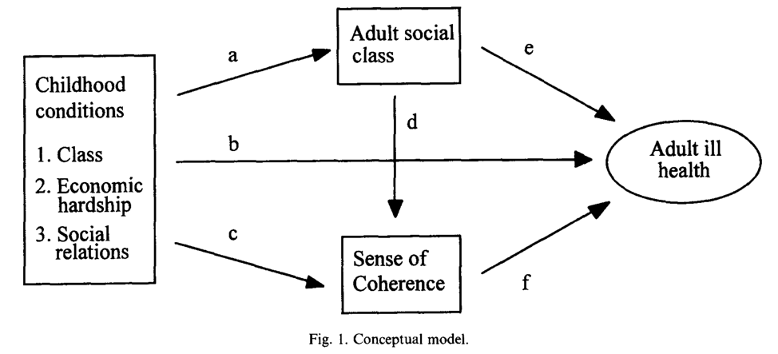

In this study specifically, analysis of adult social class and sense of coherence as intermediate factors will be omitted, and the b causal pathway will be investigated. An appropriate causal model for this study is shown below. See Figure 2.

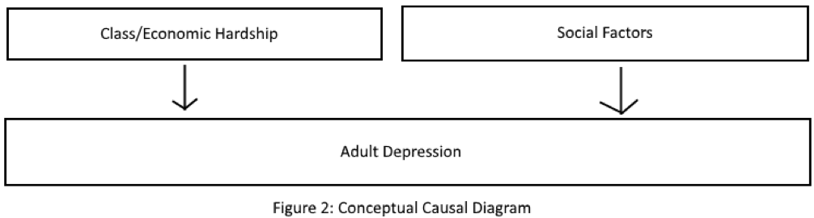

In Lundberg, social class was measured by the occupation of the father figure in the family (Lundberg 1997). However, the occupation to social class conversion is not available in this study due to the nature of the dataset (explained later). The starting point of the conceptual model for this study instead begins with social factors and the combination of social class and economic hardship, as they are usually closely related. Duncan et al. were able to show that economic deprivation and periods of family poverty during childhood affected the IQ score of the child later on in life. Children born into working class families that were constantly struggling to live were negatively affected and tested with a lower IQ than their more affluent counterparts (1994). Could these economic and social class risk factors during childhood also translate to a health disparity, specifically with the onset of adulthood depression? This study will attempt to demonstrate that abuse and death are not the only predictors of adult depression, but that childhood economic and social risk factors are also significant predictors of adulthood depression.

## Methods and Data

All of the data used in the study will be taken from the National Longitudinal Survey of Youth 1979 dataset. This dataset is chosen because it follows the American youth from childhood all the way to adulthood, which contains the time points of interest for this study. Americans born between 1962 and 1966 were interviewed for the first time in 1979, when they were between the ages of 12 and 17. Then, they were interviewed biennially until the most recent completed round, which finished in 2016 (NLSY 1979). Therefore, childhood conditions from the initial interview can be measured along with depression severity as that same respondent is an adult. However, the most important characteristic of the NLSY 1979 is that it contains two years of the CES-D survey, which is a twenty-item survey that measures the prevalence of depression symptoms based on the answers to the questions (NLSY 1979). This special section was only administered in 1992 and 1994, where the respondents be between 30 and 34 years old. The 1994 CES-D score was a result of a seven-item questionnaire, so therefore the 1992 CES-D score will be used. The method of data collection will be using responses to the interview and surveys conducted at the first round of surveying (between ages of 12 and 17) and responses in the 1992 (ages 30 and 34) round of interviewing. The original first round of surveying is used because it contains the full interview, as it is the initial one. It contains the normal respondent questions and responses, but also a parent questionnaire, which also contains valuable information on household condition. None of the other rounds administered the parent questionnaire (NSLY 1997). Similar to Lundberg 1997, economic hardship factors will be represented by the income of the family during the respondent’s childhood, specifically through the father figure’s occupation. There exists a question that asks for the annual income of the family, but it was only asked to a specific sample and had a much smaller response rate than the other questions in the survey. Therefore, two dichotomous independent variables that could represent childhood economic hardship risk factors were chosen: if the father figure in the family was generating income at age 14 and if the family was in poverty at the time of survey. Social class was measured through the occupation of the father figure in the household in Lundberg. The occupation was coded into seven different social job categories such as upper non-manual, farmer, skilled workers, and unskilled workers (Lundberg 1997). Not only was this division fairly subjective, but the social class ordering of these categories is not very defined. The NLSY 1979 data was also only able to provide the labor division of the occupation, such as manufacturing or health services (NLSY 1979). Lundberg breaks down the broad category of social relation factors into three different types: large family indicated by the number of siblings, broken home owing to death of parent, or dissension in the childhood family (1997). This study has a variable to measure each of those categories: separated parents at the age of 14 for dissension in the family, living father or mother for broken home, and number of siblings for large family. Each variable is a dichotomous variable and was for each category because it best represented the circumstance of that category. For all the dichotomous independent variables, depression score can be linearly regressed on each independent variable to analyze the covariance. The linear regression model equation of each independent on depression score is shown below. $Yi =β0 +β1Xi +εi$ Here, Y is the depression score, and X is either a 1 in case the answer given was “yes”, and a 0 if the answer given was “no”. β1 is the association between the risk factor and future adulthood depression score, with β0 being the intercept. εi is the error term associated with every prediction. The model aims to minimize the error term as much as possible.

## Concerns and Limitations

Although the National Longitudinal Survey of Youth 1979 is not a dataset specifically designed to measure mental health and early childhood conditions of individuals, it contains a wide enough range of measured information to make accurate inferences about each of the risk factors of this study. It also contains an official, widely accepted measurement of depression in the CES-D score, which was widely taken in the 1992 survey round (NLSY 1979). This study attempts to measure the viability of economic and social relation risk factors in childhood as depression risk factors, so a wide variety of questions about the household must be asked, exactly where the NLSY1997 excels.

## Intellectual Merit and Broader Impact

Studies have already shown that certain childhood risk factors, such as loss of a parent, childhood neglect, and poverty, are associated with higher risk of developing depression in adulthood (Crook and Eliot, 1980). However, childhood household conditions involve so much more than just parents and income. The home is a dynamic environment with many constantly moving parts. Circumstances change every year. The economy will rise and fall, home values will change, or the child may have to drop out of school to work in order to help support the family. The family could move to a new home, which completely changes the environment once again. The purpose of this study was to attempt to measure these economic factors as well as social relation factors to see if these were also valid predictors of the onset of adulthood depression in the future.  
If the hypothesis of this study is supported by the results, then this study will show that adulthood depression risk factors from childhood conditions embody more than just death of parent, abuse, or poverty. Depression or the risk of development would be also be predicted by an aggregate of more childhood factors, including economic and social factors, some of which play a larger role than others in contributing to changes in mindset and eventually risk of depression. The analyses presented support the broader theories, such as the life career hypothesis, which states that continuous disadvantages are more likely to continuously produce illness (Lundberg 1997). Expanding the knowledge pool on depression and anxiety risk factors is just one step in improving depression treatment in children, adolescents, and adults. Better overall understanding of risk factors can improve depression intervention techniques and can expand to better intervention for depression and anxiety related issues like suicide or panic attacks. On a broader scale, this study also offers a small step towards eliminating health inequalities that stem from economic inequalities in general, which is the overarching goal of social medicine study.